# Practical Machine Learning Course Project

Adrienne Lehnert

October 22, 2015

## Introduction

The purpose of this document is to present a model for predicting the “classe”, or style of completing a biceps curl. The model is based on a data set provided by Velloso, E. et al and presented at the Proceedings of 4th International Conference in Cooperation in Stuttgart, Germany. The model is then used to predict the classe for twenty cases in a testing data set.

### Data set

Six young health participants were asked to perform one set of 10 repetitions of the Unilateral Dumbbell Biceps Curl in five different fashions: exactly according to the specification (Class A), throwing the elbows to the front (Class B), lifting the dumbbell only halfway (Class C), lowering the dumbbell only halfway (Class D) and throwing the hips to the front (Class E). There were four sensors: an armband (arm), glove (forearm), lumbar belt, and on the dumbbell. Features were calculated on the euler angles (roll, pitch, yaw), as well as the raw accelerometer, gyroscope and magnetometer readings. The Euler angle measurements had eight features: mean, variance, standard deviation, max, min, amplitude, kurtosis and skewness.

## Building the model

The following libraries were necessary for this model:

```r
library(caret)
library(plyr)
library(dplyr)
library(AppliedPredictiveModeling)
library(rpart)
library(ipred)
```

read the data and set seed:

```r
setwd("/Users/alehnert/Documents/R")
TrData<-read.csv("pml-training.csv")
TeData<-read.csv("pml-testing.csv")
set.seed(906)
```

### Data Cleaning

Many variables are unavailable in test data, so should not be considered when building the model.  
1. values present in columns: 1:11, 37:49, 60:68, 84:86, 102, 113:124, 140, 151:160  
2. column 1 is just a row number and must be excluded or your ML algorithm will be “perfect” and completely useless! 3. columns 2-7 are also related to identifiers for the purpose of this model  
4. column 160 in training data is classe, col 160 in testing is problem number  
5. columns with variables for model are 8:59

```r
TrD<-TrData[,c(1:11,37:49,60:68,84:86,102,113:124,140,151:160)] # columns of interest in training data
TeD<-TeData[,c(1:11,37:49,60:68,84:86,102,113:124,140,151:160)] # columns of interest in testing data
TrD_original<-TrD # store original for later
inTrain<-createDataPartition(y=TrD$classe,p=0.9,list=F)
TrD<-TrD[inTrain,]; # for making models
OOSD<-TrD[-inTrain,] # out of sample data
```

### Exploratory analysis

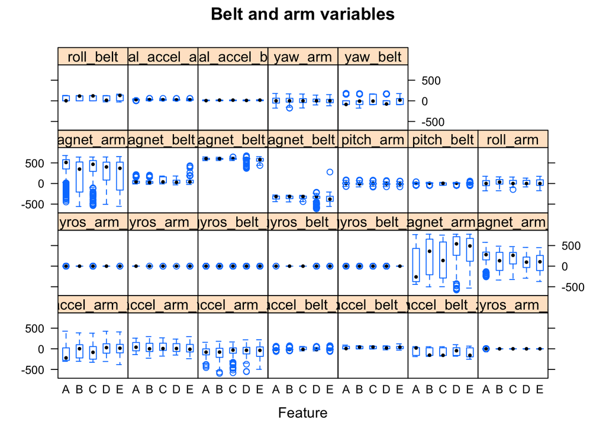

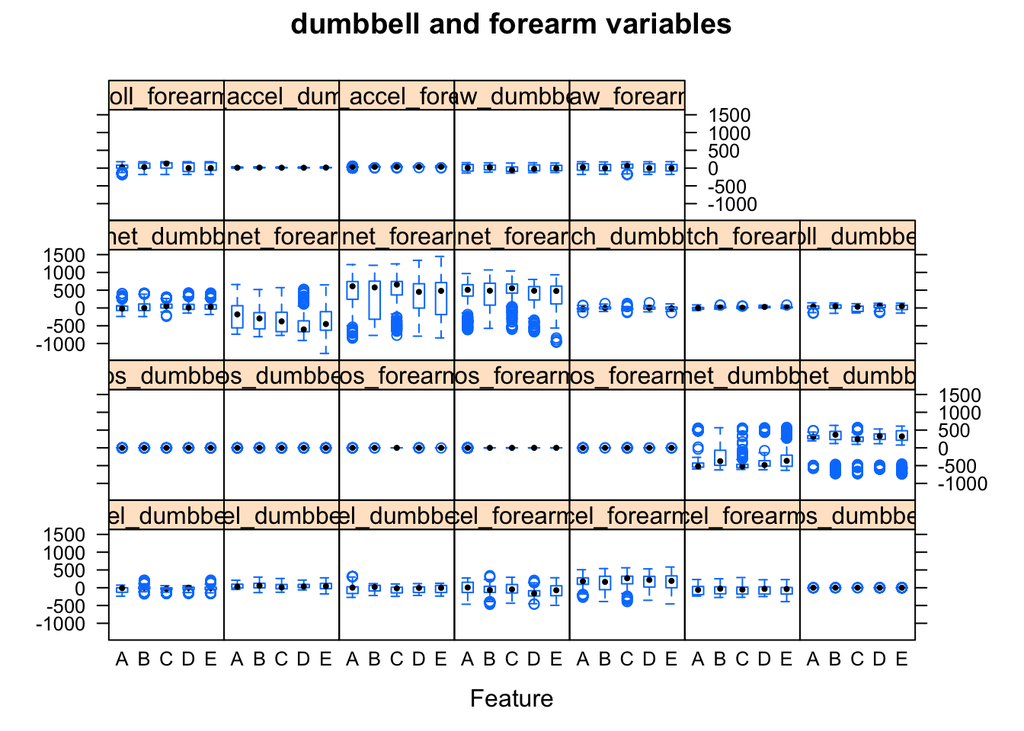

Although hard to see in this figure, it is obvious that several of the variables have means and/or distributions that would make for good variables in a machine learning algorithm. Especially interesting are the magnet and accel for the arm.

Next, I explored the relationships a little further by fitting models to each sensor’s variables and making note of which ones were most important. The variables with importance >50% were combined into a single list (ImpVarBySensor)

```r
cols<-c(8:20,60) # Columns of interest (this one for belt variables only--others are not shown here)
modFit<-train(classe~.,data=TrD[,cols],method="rpart")
print(varImp(modFit))
```

```
## rpart variable importance
##
##                  Overall
## roll_belt         100.00
## magnet_belt_y      58.48
## accel_belt_z       47.97
## gyros_belt_z       46.71
## total_accel_belt   39.49
## yaw_belt           18.50
## accel_belt_y       13.30
## gyros_belt_x        0.00
## magnet_belt_x       0.00
## magnet_belt_z       0.00
## accel_belt_x        0.00
## pitch_belt          0.00
## gyros_belt_y        0.00
```

```r
ImpVarBySensor<-c(8,19,21,23,28,31,32,34,39,44,47,48,54)
```

Alternatively, I created a potential rpart model using all variables and selected those with the highest importance (>25%) and stored them in the variable ImpVarTot

```r
modFit<-train(classe~.,data=TrD[8:60],method="rpart")
print(varImp(modFit))
```

```
## rpart variable importance
##
##   only 20 most important variables shown (out of 52)
##
##                     Overall
## pitch_forearm        100.00
## roll_forearm          73.45
## roll_belt             70.12
## magnet_dumbbell_y     49.45
## accel_belt_z          42.67
## magnet_belt_y         40.42
## yaw_belt              39.31
## magnet_dumbbell_z     36.69
## total_accel_belt      35.12
## magnet_arm_x          27.24
## accel_arm_x           26.56
## roll_dumbbell         18.43
## accel_dumbbell_y      15.29
## roll_arm              15.26
## pitch_dumbbell         0.00
## total_accel_forearm    0.00
## gyros_forearm_z        0.00
## gyros_dumbbell_z       0.00
## accel_belt_y           0.00
## gyros_dumbbell_x       0.00
```

```r
ImpVarTot<-c(8,10,11,17,19,28,31,45,46,47,48)
```

### Choosing a model

I then tried out both sets of variables (ImpVarBySensor and ImpVarTot) in rpart models with a 60/40 train/test data partition to get a rough idea regarding the accuracy (and therefore out-of-sample error) of the models:

```
## Confusion Matrix and Statistics
##
##           Reference
## Prediction    A    B    C    D    E
##          A 1725  318   20   82   90
##          B  178  631  116   94  142
##          C   59  244  993  132  133
##          D   41  167   97  785  163
##          E    5    7    6   65  770
##
## Overall Statistics
##
##                Accuracy : 0.6943
##                  95% CI : (0.6834, 0.7051)
##     No Information Rate : 0.2843
##     P-Value [Acc > NIR] : < 2.2e-16
##
##                   Kappa : 0.6123
##  Mcnemar's Test P-Value : < 2.2e-16
##
## Statistics by Class:
##
##                      Class: A Class: B Class: C Class: D Class: E
## Sensitivity            0.8591  0.46159   0.8060   0.6779   0.5932
## Specificity            0.8991  0.90695   0.9026   0.9207   0.9856
## Pos Pred Value         0.7718  0.54350   0.6361   0.6265   0.9027
## Neg Pred Value         0.9414  0.87530   0.9566   0.9358   0.9150
## Prevalence             0.2843  0.19354   0.1744   0.1640   0.1838
## Detection Rate         0.2442  0.08934   0.1406   0.1111   0.1090
## Detection Prevalence   0.3164  0.16438   0.2210   0.1774   0.1208
## Balanced Accuracy      0.8791  0.68427   0.8543   0.7993   0.7894
```

```
## Confusion Matrix and Statistics
##
##           Reference
## Prediction    A    B    C    D    E
##          A 1703  256   18  104   82
##          B  124  853  202  160  252
##          C   50  159  905  161  143
##          D  124   99  107  706  123
##          E    7    0    0   27  698
##
## Overall Statistics
##
##                Accuracy : 0.6888
##                  95% CI : (0.6779, 0.6996)
##     No Information Rate : 0.2843
##     P-Value [Acc > NIR] : < 2.2e-16
##
##                   Kappa : 0.6053
##  Mcnemar's Test P-Value : < 2.2e-16
##
## Statistics by Class:
##
##                      Class: A Class: B Class: C Class: D Class: E
## Sensitivity            0.8481   0.6240   0.7346  0.60967  0.53775
## Specificity            0.9090   0.8704   0.9120  0.92329  0.99410
## Pos Pred Value         0.7873   0.5361   0.6382  0.60915  0.95355
## Neg Pred Value         0.9378   0.9061   0.9421  0.92344  0.90523
## Prevalence             0.2843   0.1935   0.1744  0.16395  0.18377
## Detection Rate         0.2411   0.1208   0.1281  0.09996  0.09882
## Detection Prevalence   0.3062   0.2253   0.2008  0.16409  0.10364
## Balanced Accuracy      0.8786   0.7472   0.8233  0.76648  0.76593
```

As seen in the statistics, the confidence intervals for the two options overlap so there is no significant difference in the accuracies. I chose to use the later (ImpVarTot, or the one based on the most important variables fit all at once), as it uses fewer variables and is thus faster and less prone to overfitting.

Next I took a closer look at the potential out-of-sample error. I simulated fitting the model to 80% of the training data and testing with the other 20% many times and histogrammed the out-of-sample error level for each iteration. I also chose the parameters of the most accurate and saved it as the final version of fitByTot

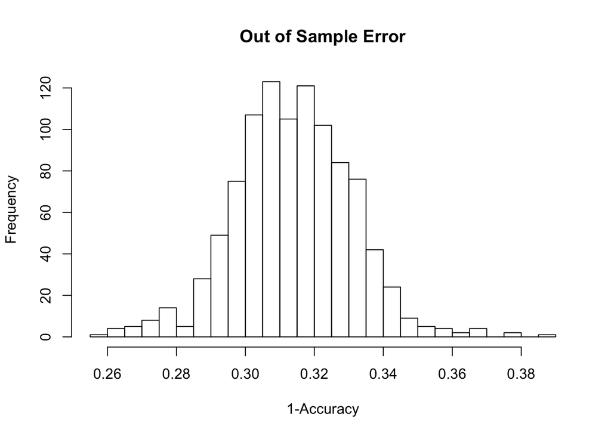

```
## [1] "The most accurate model had an out of sample error estimate of  0.26"
```

Here is the proposed model:

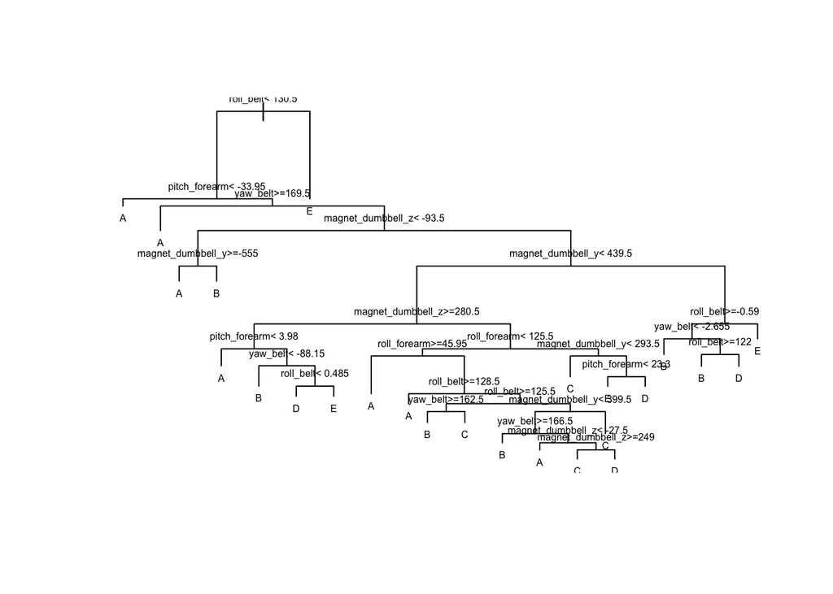

A look at the cp table shows that the cross-validation error (xerror) is at its lowest point as is and does not need further pruning.

```r
printcp(fitByTot) # Display the cp (components) table
```

```
##
## Classification tree:
## rpart(formula = classe ~ ., data = trainD[, c(ImpVarTot, 60)],
##     method = "class")
##
## Variables actually used in tree construction:
## [1] magnet_dumbbell_y magnet_dumbbell_z pitch_forearm     roll_belt
## [5] roll_forearm      yaw_belt
##
## Root node error: 7585/10599 = 0.71563
##
## n= 10599
##
##          CP nsplit rel error  xerror      xstd
## 1  0.116282      0   1.00000 1.00000 0.0061230
## 2  0.039189      1   0.88372 0.88451 0.0065421
## 3  0.033092      5   0.72696 0.72472 0.0067818
## 4  0.025928      6   0.69387 0.69453 0.0067864
## 5  0.024786      9   0.61608 0.63837 0.0067612
## 6  0.020303     11   0.56651 0.59644 0.0067135
## 7  0.019908     13   0.52591 0.57337 0.0066765
## 8  0.017666     14   0.50600 0.53026 0.0065864
## 9  0.015557     17   0.45300 0.48965 0.0064757
## 10 0.014502     18   0.43744 0.46355 0.0063906
## 11 0.013448     19   0.42294 0.45392 0.0063565
## 12 0.012788     20   0.40949 0.44047 0.0063061
## 13 0.012129     21   0.39670 0.43283 0.0062760
## 14 0.010481     22   0.38457 0.40593 0.0061621
## 15 0.010000     24   0.36361 0.39222 0.0060988
```

Finally, I applied the final model discussed above, fitByTot, to the reserved data to get the out of sample error. Note that this out of sample error is very close to the estimated out of sample error found earlier thanks to those cross-validation efforts.

```r
Pfinal<-predict(fitByTot,newdata=OOSD[,c(ImpVarTot,60)],type="class")
confusionMatrix(Pfinal,OOSD$classe)
```

```
## Confusion Matrix and Statistics
##
##           Reference
## Prediction   A   B   C   D   E
##          A 428  56   4  15  18
##          B  34 240  43  17  25
##          C  10  27 213  41  41
##          D  16  12  22 197  12
##          E  11  23  13  14 234
##
## Overall Statistics
##
##                Accuracy : 0.7429
##                  95% CI : (0.7219, 0.7632)
##     No Information Rate : 0.2826
##     P-Value [Acc > NIR] : < 2.2e-16
##
##                   Kappa : 0.6743
##  Mcnemar's Test P-Value : 0.0001418
##
## Statistics by Class:
##
##                      Class: A Class: B Class: C Class: D Class: E
## Sensitivity            0.8577   0.6704   0.7220   0.6937   0.7091
## Specificity            0.9266   0.9155   0.9191   0.9582   0.9575
## Pos Pred Value         0.8215   0.6685   0.6416   0.7606   0.7932
## Neg Pred Value         0.9430   0.9161   0.9428   0.9423   0.9347
## Prevalence             0.2826   0.2027   0.1670   0.1608   0.1869
## Detection Rate         0.2424   0.1359   0.1206   0.1116   0.1325
## Detection Prevalence   0.2950   0.2033   0.1880   0.1467   0.1670
## Balanced Accuracy      0.8922   0.7929   0.8206   0.8259   0.8333
```

```
## [1] "Out of sample error is: 0.26"
```

## Discussion

In the orginal paper by Velloso, E. et al, the authors discuss the model they chose:

“17 features were selected: in the belt, were selected the mean and variance of the roll, maximum, range and variance of the accelerometer vector, variance of the gyro and variance of the magnetometer. In the arm, the variance of the accelerometer vector and the maximum and minimum of the magnetometer were selected. In the dumbbell, the selected features were the maximum of the acceleration, variance of the gyro and maximum and minimum of the magnetometer, while in the glove, the sum of the pitch and the maximum and minimum of the gyro were selected.”